# STA141Aproject

Franklin Hong

2023-06-06

# Predicting the Outcome of Mice Behavior Using Stimuli, Analysis of Brain Data, and Predictive Modeling

# Abstract

The primary objective of this project is to build a predictive model to predict the outcome (i.e., feedback type) of each trial using the neural activity data (i.e., spike trains in spks), along with the stimuli (the left and right contrasts). To do so, we explore the given data such as the neurons within mice, spikes in relation with time bins, and such. We integrate data using a PCA model and use our findings to creative a predictive model using a kNN model.

# Section 1 Introduction. Introduce the objective and briefly review the background of this data set.

We are presented with research (Steinmetz et al., 2019) that provides an analysis of the neural activity of four mice. The analysis is based on mice turning a wheel in accordance with a visual stimulus or contrasting stimuli. The feedback (1 or -1) either rewards or punishes the mice depending on whether or not they turned the wheel in the correct direction.

# Section 2 Exploratory analysis.

The given article defines 6 variables used to conduct the experiment:

feedback_type: type of the feedback, 1 for success and -1 for failure

contrast_left: contrast of the left stimulus

contrast_right: contrast of the right stimulus

time: centers of the time bins for spks

spks: number of spikes of neurons in the visual cortex in time bins defined in time

brain_area: area of the brain where each neuron lives

```
## Session 1 -- 734 neurons and 114 trials.
## Session 2 -- 1070 neurons and 251 trials.
## Session 3 -- 619 neurons and 228 trials.
## Session 4 -- 1769 neurons and 249 trials.
## Session 5 -- 1077 neurons and 254 trials.
## Session 6 -- 1169 neurons and 290 trials.
## Session 7 -- 584 neurons and 252 trials.
## Session 8 -- 1157 neurons and 250 trials.
## Session 9 -- 788 neurons and 372 trials.
## Session 10 -- 1172 neurons and 447 trials.
## Session 11 -- 857 neurons and 342 trials.
## Session 12 -- 698 neurons and 340 trials.
## Session 13 -- 983 neurons and 300 trials.
## Session 14 -- 756 neurons and 268 trials.
## Session 15 -- 743 neurons and 404 trials.
## Session 16 -- 474 neurons and 280 trials.
## Session 17 -- 565 neurons and 224 trials.
## Session 18 -- 1090 neurons and 216 trials.
```

We can see that within all 18 sessions, there are a varying number of neurons nearing the thousands and around 200 to 450 trials excluding Session 1, where there are only 114 trials. Note that for each trial in a session, the number of neurons stay the same. Each session carries a differing amount of neurons.

[figure not shown]

[figure not shown]

```r
# View data and variables

# feedback_type <- session[[5]]$feedback_type[[11]]
# contrast_left <- session[[5]]$contrast_left[[11]]
# contrast_right <- session[[5]]$contrast_right[[11]]
# time <- session[[5]]$time
# spks <- session[[5]]$spks[[11]]
# brain_area <- session[[5]]$brain_area
# print(session[[5]]$feedback_type)
```

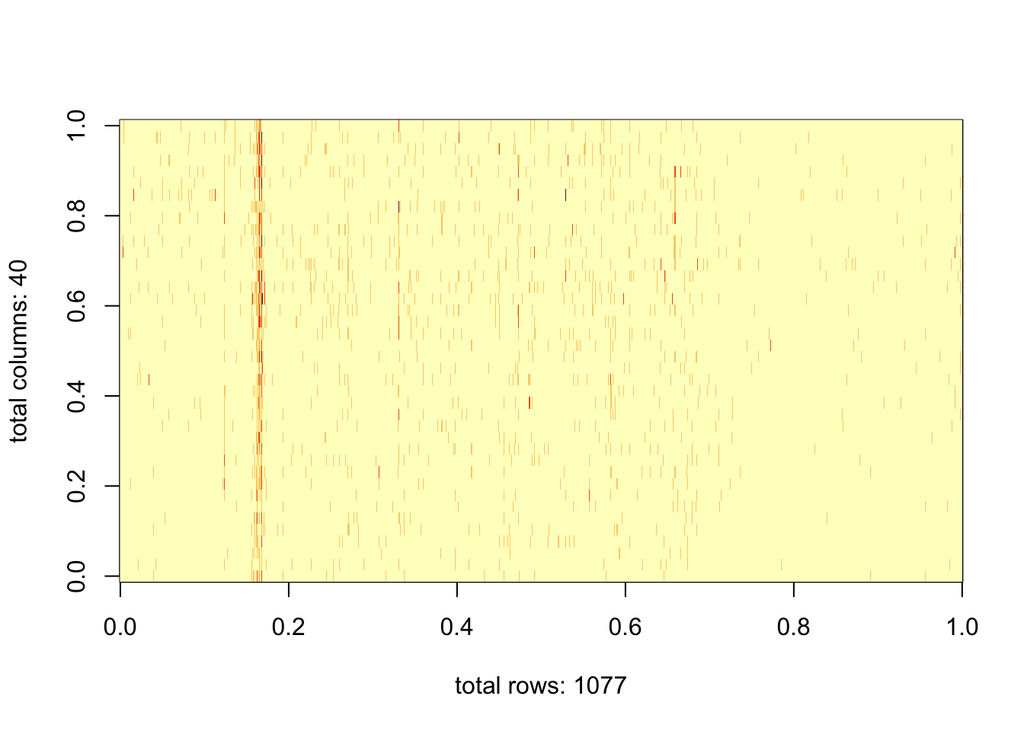

```
## trial: 1 feedback_type: 1 contrast_left: 0 contrast_right: 1
```

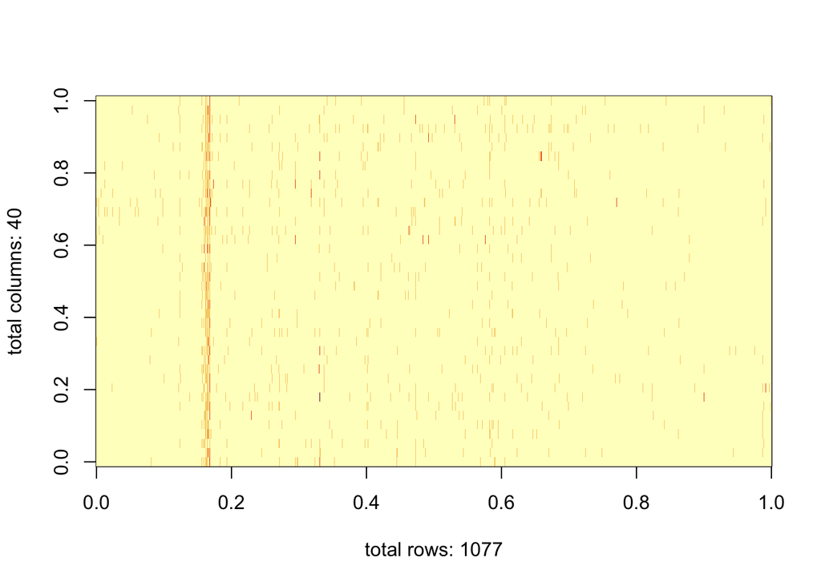

```
## trial: 2 feedback_type: 1 contrast_left: 0 contrast_right: 0
```

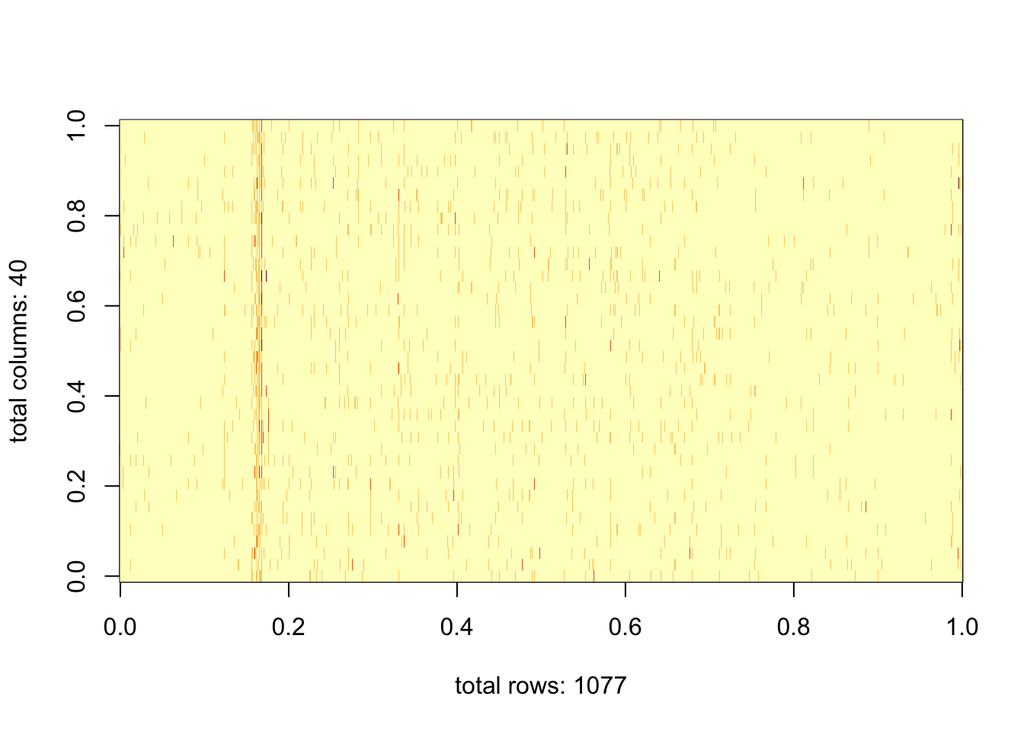

```
## trial: 3 feedback_type: -1 contrast_left: 0.25 contrast_right: 0.25
```

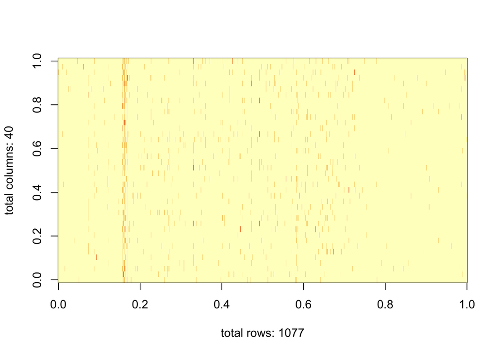

```
## trial: 4 feedback_type: -1 contrast_left: 0 contrast_right: 0
```

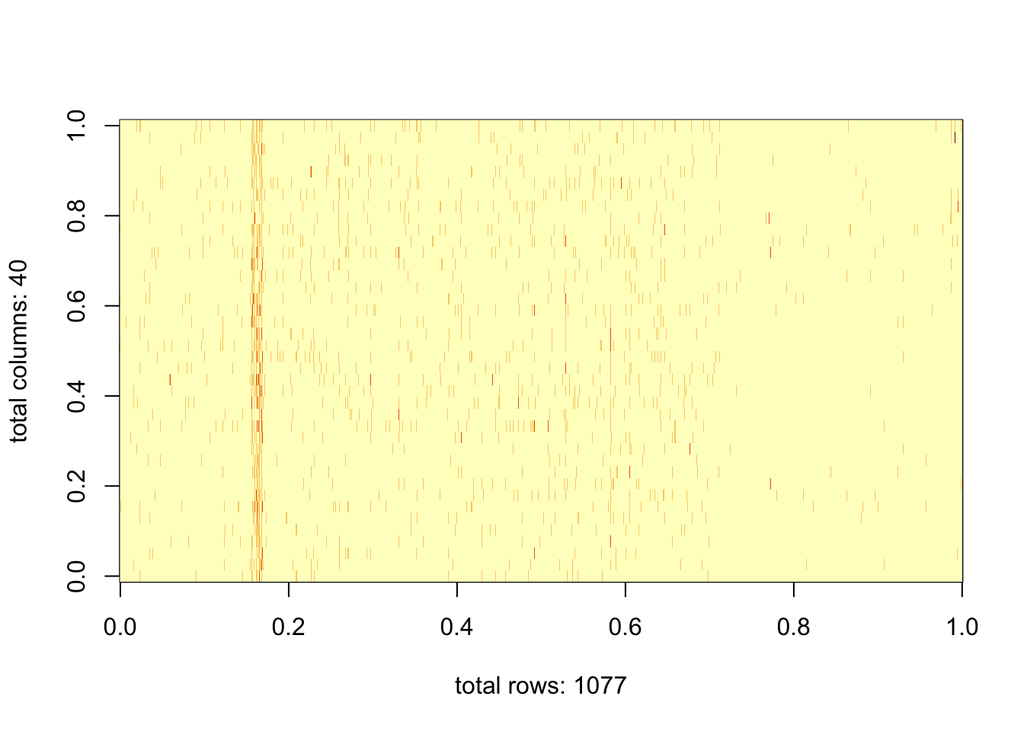

```
## trial: 5 feedback_type: 1 contrast_left: 0 contrast_right: 0
```

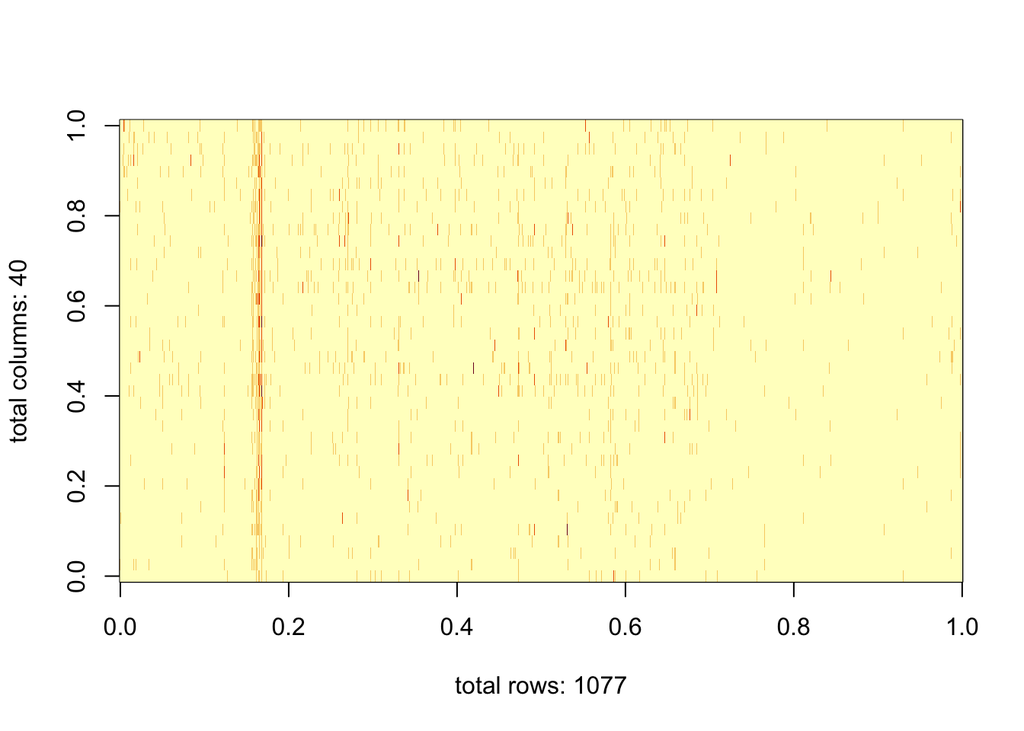

```
## trial: 6 feedback_type: 1 contrast_left: 0.5 contrast_right: 1
```

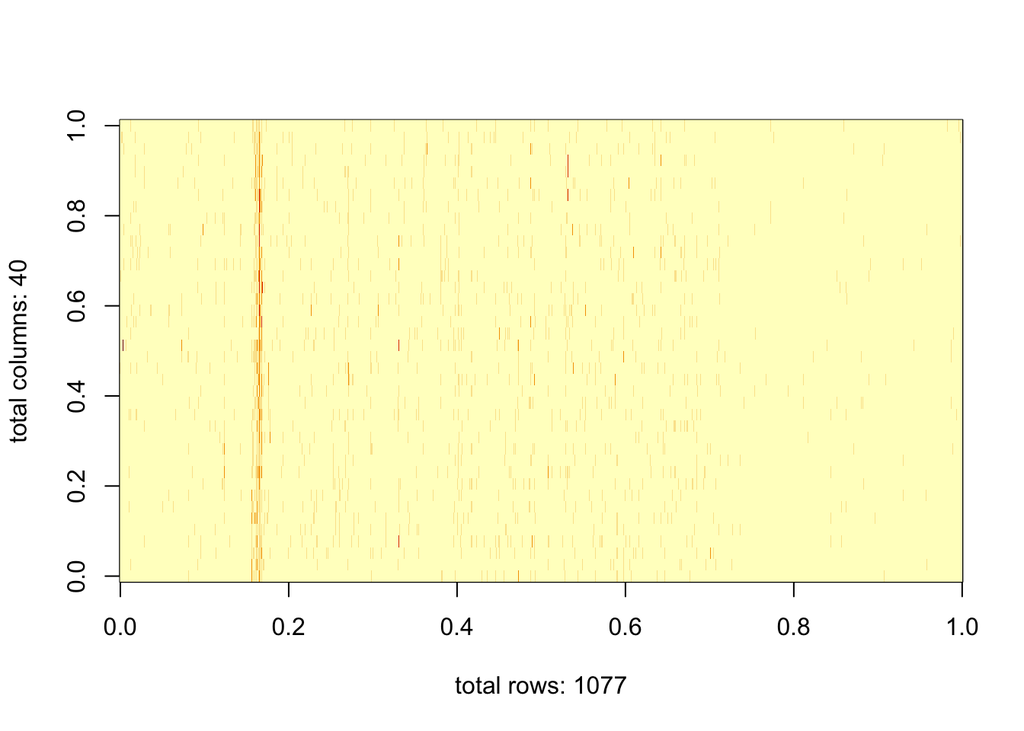

```
## trial: 7 feedback_type: 1 contrast_left: 0 contrast_right: 0.5
```

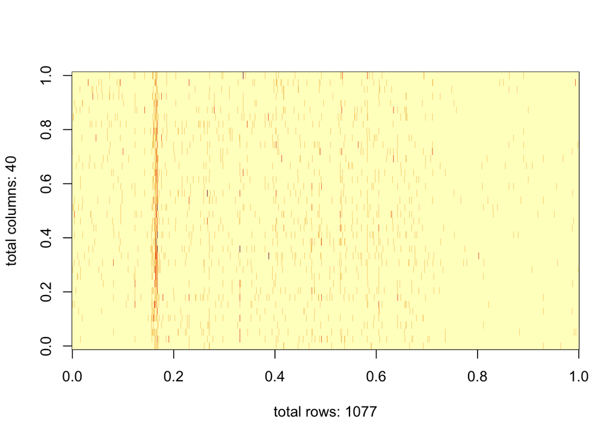

```
## trial: 8 feedback_type: 1 contrast_left: 0.5 contrast_right: 1
```

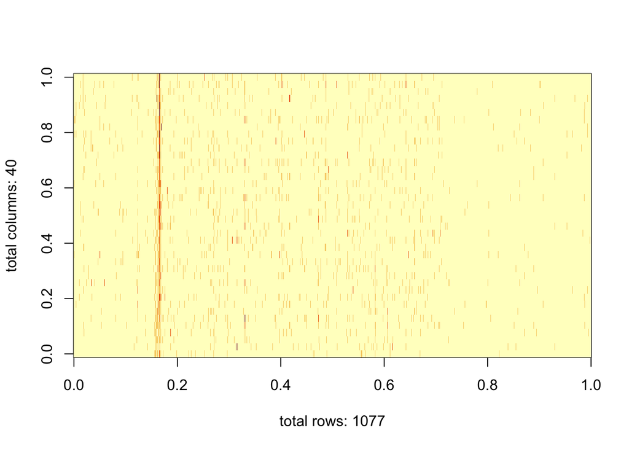

```
## trial: 9 feedback_type: 1 contrast_left: 0.5 contrast_right: 1
```

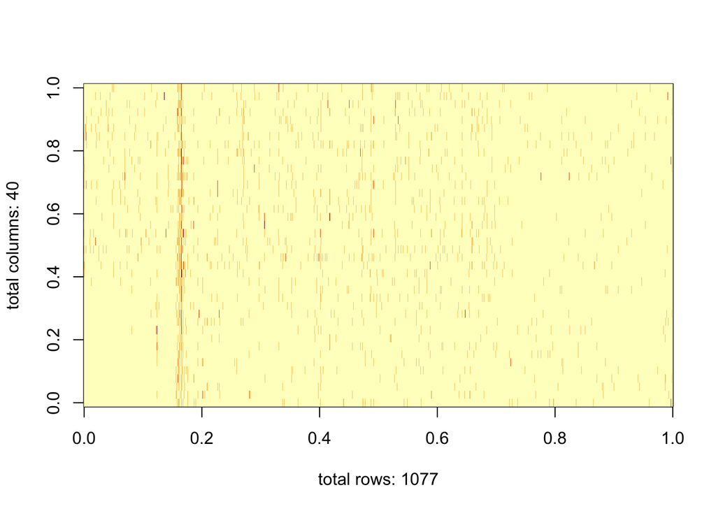

```
## trial: 10 feedback_type: 1 contrast_left: 0.25 contrast_right: 1
```

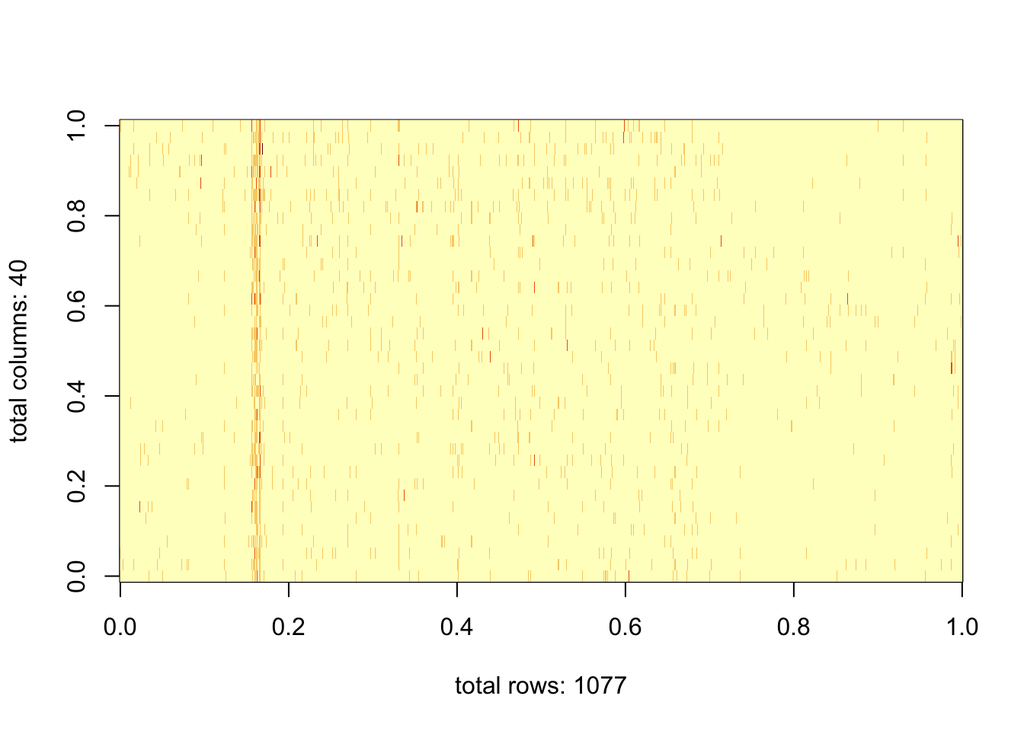

```
## trial: 11 feedback_type: 1 contrast_left: 1 contrast_right: 0
```

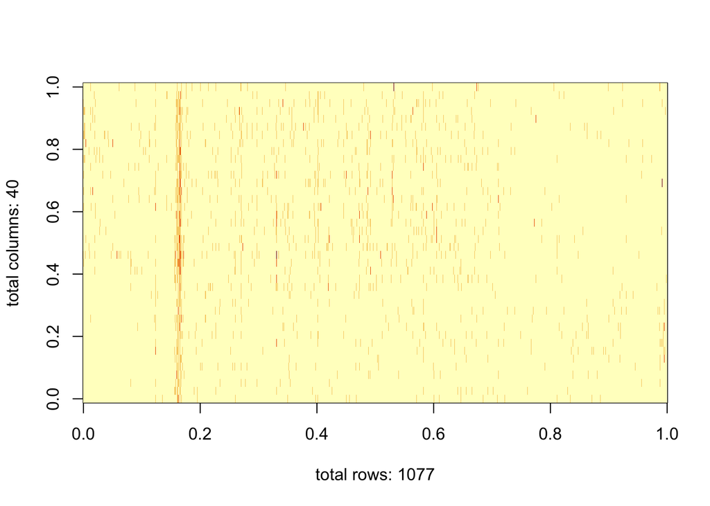

```
## trial: 12 feedback_type: 1 contrast_left: 0.25 contrast_right: 0.5
```

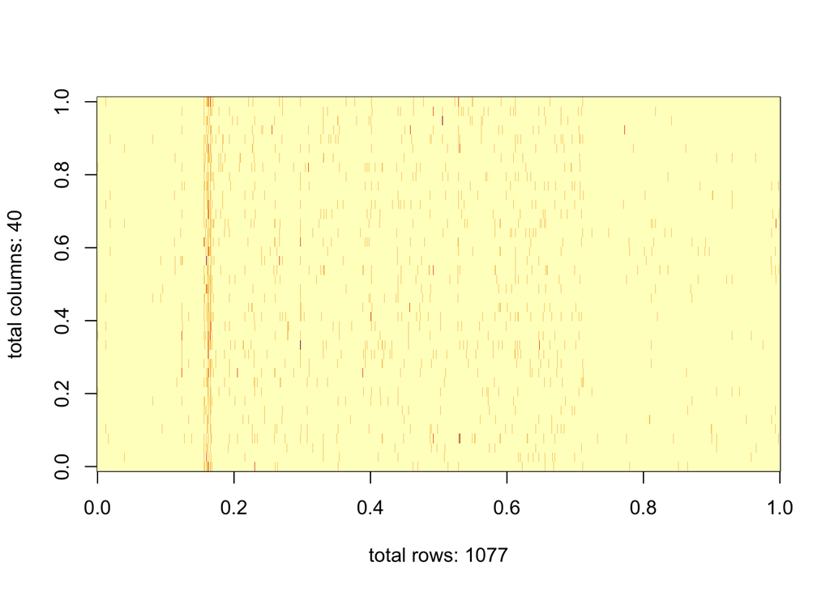

```
## trial: 13 feedback_type: -1 contrast_left: 0 contrast_right: 0.25
```

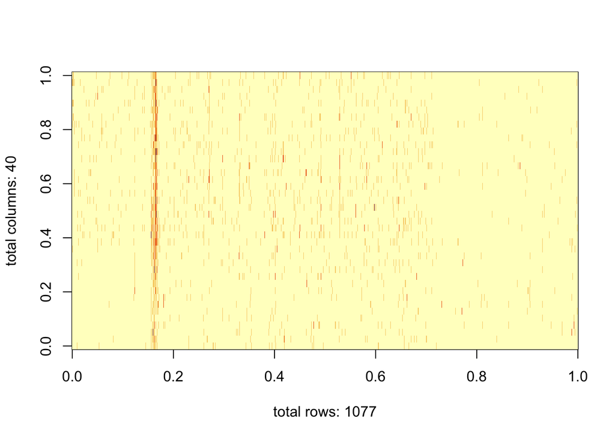

```
## trial: 14 feedback_type: 1 contrast_left: 1 contrast_right: 1
```

# Section 3 Data integration.

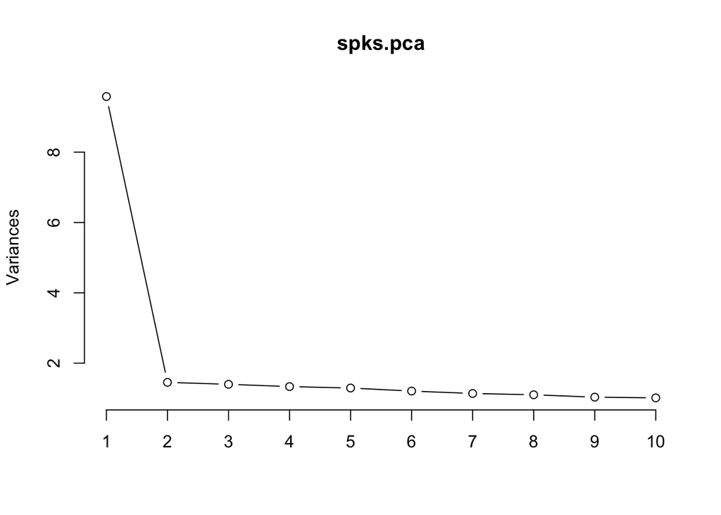

```r
# PCA

spks.pca <- session[[5]]$spks[[11]] %>% prcomp(center = TRUE, scale = TRUE)
plot(spks.pca, type = "lines")
```

```r
spks.pca4 = spks.pca$x[, 4]
spks.pca4
```

[output not shown]

[output cut: 201 more lines]

The line plot compares the PCA to their variances. For the sake of our matrix for kNN testing, we will be utilizing PCA4 as it has the least slope when also observing the variance of its neighbors PC3 and PC5.

# Section 4 Predictive modeling.

```r
#PCA -> kNN testing

feedback.1.trial = data.frame()
feedback.1.not.trial = data.frame()
for (i in 10){
  session[[i]]=readRDS(paste('session',i,'.rds',sep=''))
  for (j in 1:length(session[[i]]$contrast_left)){
    spks.pca <- prcomp(session[[i]]$spks[[j]], center = TRUE, scale = TRUE)
    spks.pca.rotated <- spks.pca$rotation[,4]
    row = c(value1 = session[[i]]$feedback_type[j], session[[i]]$contrast_left[j], session[[i]]$contrast_right[j], spks.pca.rotated)
    if (session[[i]]$feedback_type[j] == 1){
    feedback.1.trial <- rbind(feedback.1.trial, row)
    }
    if (session[[i]]$feedback_type[j] == -1){
    feedback.1.not.trial <- rbind(feedback.1.not.trial, row)
    }


  }
}
column = c("feedback_type", "contrast_left", "contrast_right", paste0("spks", 1:40))
names(feedback.1.trial) = column
names(feedback.1.not.trial) = column
feedback.1.train.data = feedback.1.trial[1:125, ]
feedback.1.not.train.data = feedback.1.not.trial[1:125, ]
train.data = rbind(feedback.1.train.data, feedback.1.not.train.data)

feedback.1.test.data = feedback.1.trial[126:170, ]
feedback.1.not.test.data = feedback.1.not.trial[126:170, ]
test.data = rbind(feedback.1.test.data, feedback.1.not.test.data)

knn.model.k1 <- knn(train.data, test.data, cl = session[[i]]$feedback_type[1:250], k = 1)

confusion.matrix.1 <- table(session[[i]]$feedback_type[1:length(knn.model.k1)], knn.model.k1)
misclassification.rate.1 <- 1 - sum(diag(confusion.matrix.1)) / sum(confusion.matrix.1)
print(misclassification.rate.1)
```

```
## [1] 0.4666667
```